# Презентация по лабораторной работе №5

Операционные системы

Сокирка Анна Константиновна

# Цель работы

Познакомиться с pass, gopass, chezmoi, научиться ими пользоваться

# Задания

1. Установить дополнительное ПО
2. Установить и настроить pass
3. Настроить интерфейс с браузером
4. Установить и настроить chezmoi

# Выполнение лабораторной работы

##Установка и настройка менеджера паролей pass

Перешла в режим суперпользователя и начинаю установку pass (рис. [-@fig:001]).

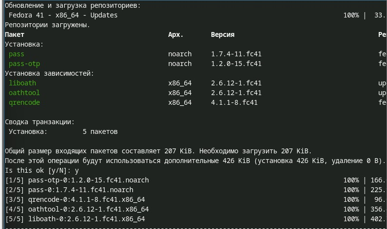

1

Устанавливаю gopass(рис. [-@fig:002]).

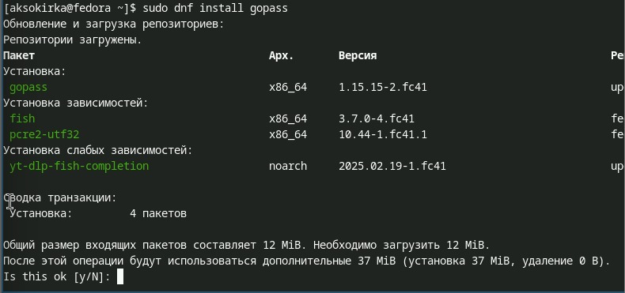

2

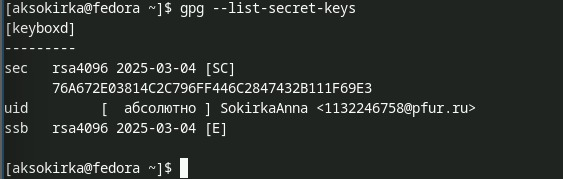

3

Инициализирую хранилище, синхронизирую с гит и создаю структуру гит(рис. [-@fig:004]).

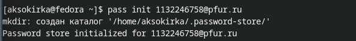

4

##Настройка интерфейса с броузером

[figure not shown]

5

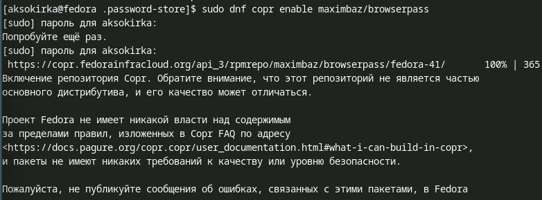

6

Созддаю файл с паролем(рис. [-@fig:007]).

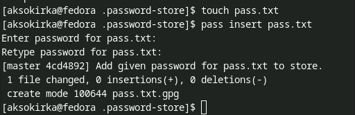

7

Отображаю созданный пароль(рис. [-@fig:008]).

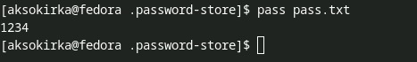

8

Заменяю пароль на сгенерированный автоматически(рис. [-@fig:009]).

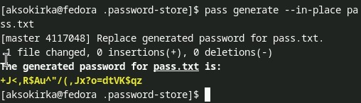

9

##Управление файлами конфигурации

Устанавливаю дополнительное программное обеспечение(рис. [-@fig:010]).

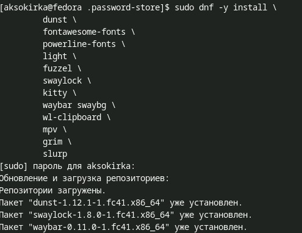

10

Устанавливаю шрифты(рис. [-@fig:011]).

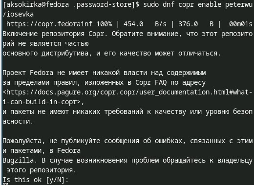

11

Устанавливаю бинарный файл и создаю собственный репозиторий с помощью утилит(рис. [-@fig:012]).

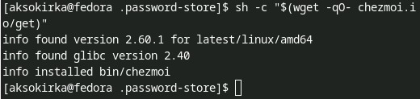

12

##Использование chezmoi на нескольких машинах

На второй машине инициализирую chezmoi с моим репозиторием dotfiles(рис. [-@fig:013]).

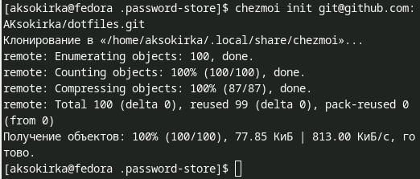

13

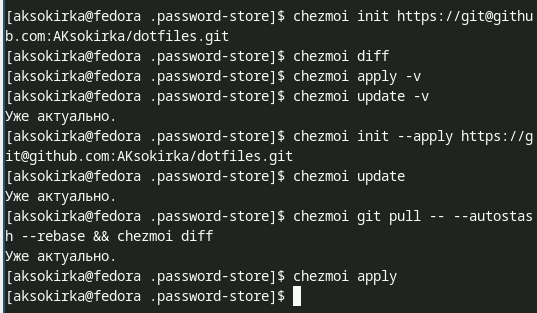

14

# Выводы

В ходе выполнения работы я познакомилась с pass, gopass, chezmoi, научилась ими пользоваться

# Список литературы

1. Лабораторная работа 5